# Yelp Capstone Project

Aiko Liu

September 2, 2016

## Data EDA

Either include the directory of ParseJSON.py into the sys.path list, or cd to that directory.

```python
from ParseJSON import ParseJSON, ProcessID
data_business = ParseJSON('dirName/yelp_academic_dataset_business.json')
len(data_business) # 77445
data_business[0]
#{'attributes': {'Accepts Credit Cards': True,
#  'Alcohol': 'none',
#  'Ambience': {'casual': False,
#   'classy': False,
#   'divey': False,
#   'hipster': False,
#   'intimate': False,
#   'romantic': False,
#   'touristy': False,
#   'trendy': False,
#   'upscale': False},
#  'Attire': 'casual',
#  'Caters': False,
#  'Delivery': False,
#  'Drive-Thru': False,
#  'Good For': {'breakfast': False,
#   'brunch': False,
#   'dessert': False,
#   'dinner': False,
#   'latenight': False,
#   'lunch': False},
#  'Good For Groups': True,
#  'Good for Kids': True,
#  'Has TV': False,
#  'Noise Level': 'average',
#  'Outdoor Seating': False,
#  'Parking': {'garage': False,
#   'lot': False,
#   'street': False,
#   'valet': False,
#   'validated': False},
#  'Price Range': 1,
#  'Take-out': True,
#  'Takes Reservations': False,
#  'Waiter Service': False},
# 'business_id': '5UmKMjUEUNdYWqANhGckJw',
# 'categories': ['Fast Food', 'Restaurants'],
# 'city': 'Dravosburg',
# 'full_address': '4734 Lebanon Church Rd\nDravosburg, PA 15034',
# 'hours': {'Friday': {'close': '21:00', 'open': '11:00'},
#  'Monday': {'close': '21:00', 'open': '11:00'},
#  'Thursday': {'close': '21:00', 'open': '11:00'},
#  'Tuesday': {'close': '21:00', 'open': '11:00'},
#  'Wednesday': {'close': '21:00', 'open': '11:00'}},
# 'latitude': 40.3543266,
# 'longitude': -79.9007057,
# 'name': 'Mr Hoagie',
# 'neighborhoods': [],
# 'open': True,
# 'review_count': 4,
# 'stars': 4.5,
# 'state': 'PA',
# 'type': 'business'}
```

In general, the output of ParseJSON is a list of json objects, represented by a NESTED dictionary. To access the average ‘stars’ and business categories of each business, we

```python
stars = ProcessID(data_business,'stars')
# stars is a list of numbers

# stars[:10]
#[4.5, 3.5, 5.0, 2.5, 2.5, 5.0, 2.5, 4.0, 2.5, 4.0]

categories = ProcessID(data_business,'categories')
# Because each business can belong to more than one category (alphebatically sorted),
# categories is a list of lists of strings.

# categories[:10]

#[['Fast Food', 'Restaurants'],
# ['Nightlife'],
# ['Auto Repair', 'Automotive'],
# ['Active Life', 'Mini Golf', 'Golf'],
# ['Shopping',
#  'Home Services',
#  'Internet Service Providers',
#  'Mobile Phones',
#  'Professional Services',
#  'Electronics'],
# ['Bars', 'American (New)', 'Nightlife', 'Lounges', 'Restaurants'],
# ['Active Life', 'Trainers', 'Fitness & Instruction'],
# ['Bars', 'American (Traditional)', 'Nightlife', 'Restaurants'],
# ['Auto Repair', 'Automotive', 'Tires'],
# ['Active Life', 'Mini Golf']]
```

ProcessID peels off the data layer by layer, similar to ‘beautiful soup’. Based on this technique, we find that

- basic info on the review file: 2225213 reviews, 3798 different dates (about 10 years), 5 different star level, 77079 distinct business IDs, 552339 different usersID, only 1 type of review (so ‘type’ seems to be redundant)
- check in data has 55569 unique business ID. So each line is a different business
- The business location covers 29 different states. 66878 are still open, 10567 are closed
- There are 892 different business categories in the data set.

```python
# top 50 business categories
[('Restaurants', 25071),
 ('Shopping', 11233),
 ('Food', 9250),
 ('Beauty & Spas', 6583),
 ('Health & Medical', 5121),
 ('Nightlife', 5088),
 ('Home Services', 4785),
 ('Bars', 4328),
 ('Automotive', 4208),
 ('Local Services', 3468),
 ('Active Life', 3103),
 ('Fashion', 3078),
 ('Event Planning & Services', 2975),
 ('Fast Food', 2851),
 ('Pizza', 2657),
 ('Mexican', 2515),
 ('Hotels & Travel', 2495),
 ('American (Traditional)', 2416),
 ('Sandwiches', 2364),
 ('Arts & Entertainment', 2271),
 ('Coffee & Tea', 2199),
 ('Hair Salons', 2091),
 ('Italian', 1848),
 ('Burgers', 1774),
 ('Auto Repair', 1716),
 ('Doctors', 1694),
 ('Nail Salons', 1667),
 ('Chinese', 1629),
 ('American (New)', 1593),
 ('Home & Garden', 1586),
 ('Pets', 1497),
 ('Fitness & Instruction', 1442),
 ('Hotels', 1431),
 ('Grocery', 1424),
 ('Real Estate', 1424),
 ('Breakfast & Brunch', 1369),
 ('Dentists', 1195),
 ('Specialty Food', 1150),
 ("Women's Clothing", 1138),
 ('Bakeries', 1115),
 ('Professional Services', 1025),
 ('Ice Cream & Frozen Yogurt', 1018),
 ('Cafes', 1002),
 ('Financial Services', 875),
 ('Pubs', 874),
 ('Pet Services', 870),
 ('Japanese', 848),
 ('General Dentistry', 823),
 ('Sports Bars', 818),
 ('Sushi Bars', 798)]
```

- Because each business often has more than one category attribute (alphebatically sorted), it is not easy to determine which is the dominant category from the ‘categories’ list.
- Among the 70K+ business, there are 50K+ receiving single digit customer reviews. Only 20K business receive >=20 reviews
- The ‘Mon Ami Gabi restaurant’ in Las Vegas has 5642 customer yelp reviews. This is the most reviewed business

We also plot a few histograms,

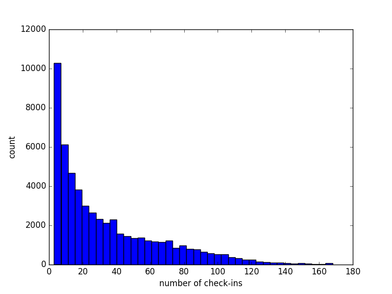

Customer Yelp CheckIn Histogram.

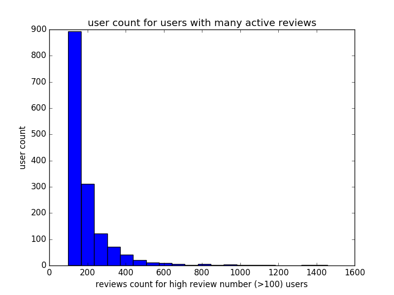

Customer Yelp ActiveUsers Histogram.

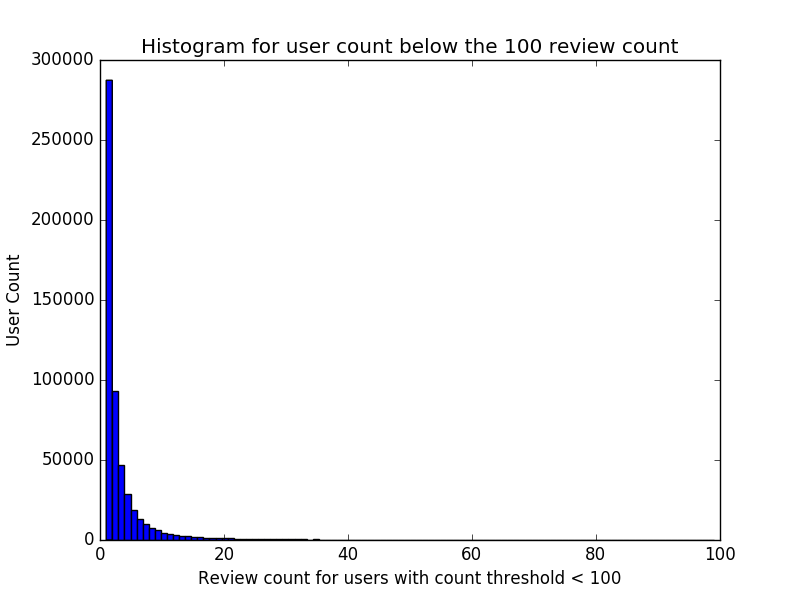

Customer Yelp InActive Users Histogram.

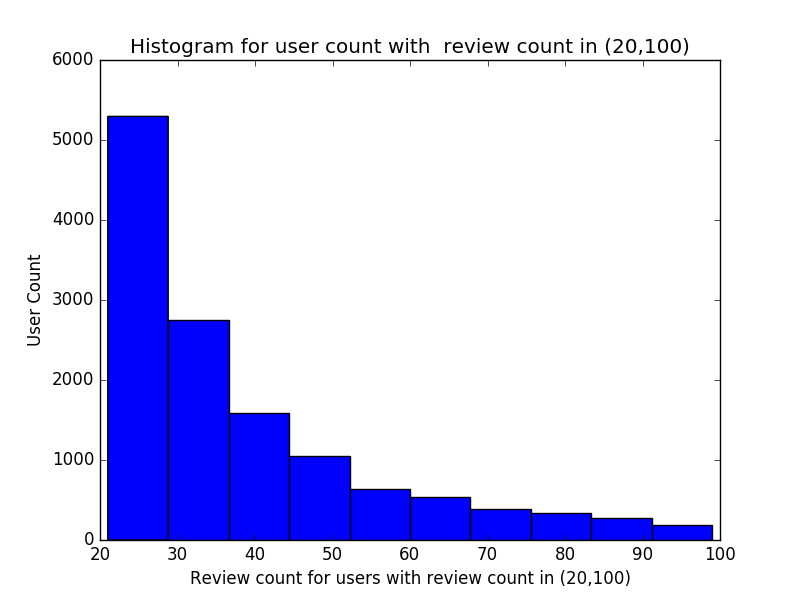

Customer Yelp mid range Active Users Histogram.

- It is difficult to plot these into a single histogram. There are too many inactive users which dwarf the numbers of the very active users.

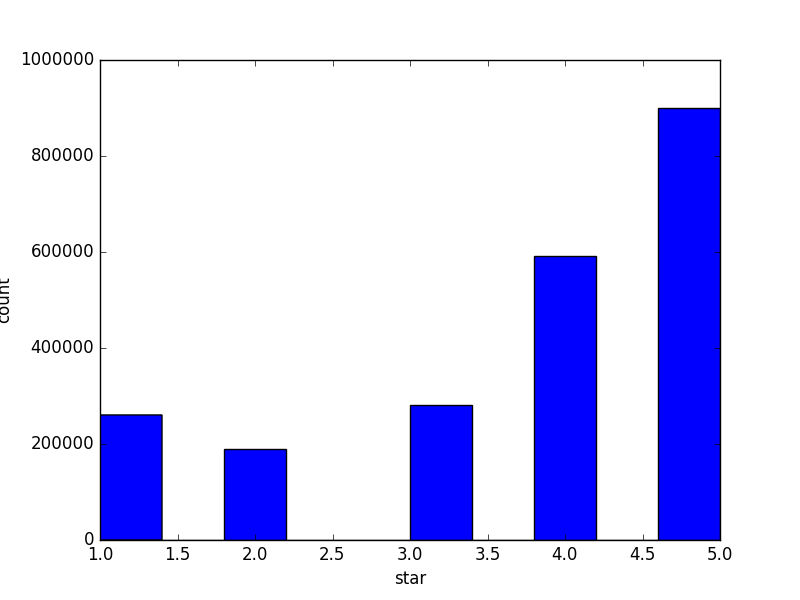

Customer Yelp review stars Histogram.

- It seems that the data has some ‘review bias’. Most of the reviews are >=3 stars.

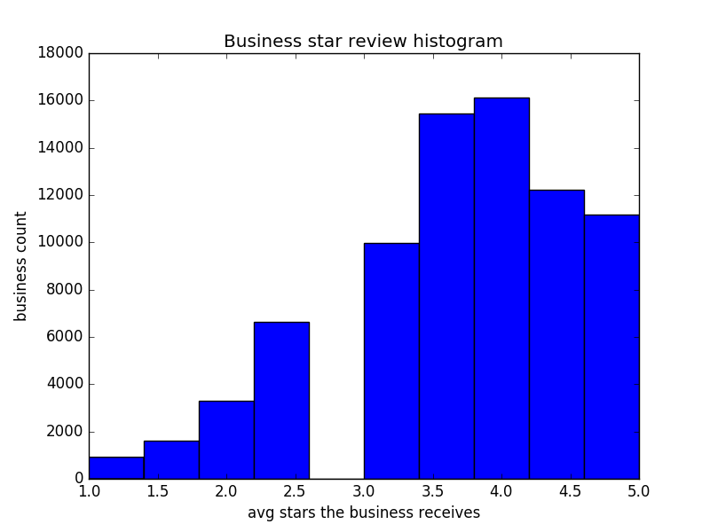

Business Yelp review stars Histogram.